# Chromatin conformation reconstruction via PoisMS package

Elena Tuzhilina

February 22, 2020

# Introduction

PoisMS package contains implementation of Principal Curve-based methods for chromatin reconstruction. The input data is a *contact map* $C\in\mathbf{Z}^{n\times n}$, a symmetric integer-valued matrix of contact counts between $n$ binned genomic loci on a genome-wide basis. The goal is to use the contact matrix $C$ to obtain spatial coordinates $x_1, \ldots, x_n\in \mathbb{R}^3$ of genomic loci $1, \ldots, n,$ respectively.

# Contact matrix

In our experiments we use Hi-C data for IMR90 cells for chromosome 20 and resolution 100kb obtained from the Gene Expression Omnibus (check the package for different Hi-C data available).

```r
library(PoisMS)
data(IMR90_100kb_chr20)
C = data.matrix(IMR90_100kb_chr20)
n = ncol(C)
```

Usually, contact matrices are diagonally dominant, so we apply log-transformation along with some centering and scaling to the contact matrix prior to visualizing it, i.e. we consider $C^{\log} = \frac{\log(C+\epsilon)-\beta }{\alpha}$.

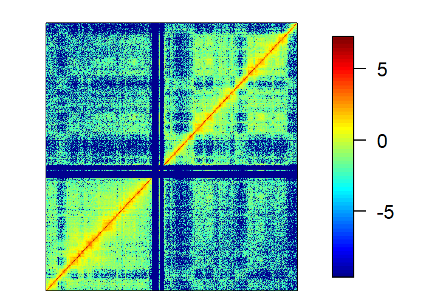

```r
library(fields)
alpha = 1
eps = 0.001
beta = log(mean(C))
Clog = (log(C + eps) - beta)/alpha
par(mar = c(0, 2, 1, 2))
image.plot(Clog, xaxt='n', yaxt = 'n', mar = c(0, 2, 1, 2))
```

Note that there are some unobserved loci near the centromere; we save the genomic coordinates of $599$ observed loci and drop unobserved ones from the contact matrix.

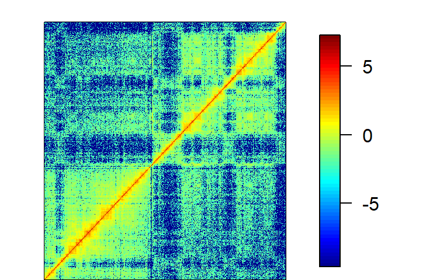

```r
index = which(diag(C) != 0)
n_obs = length(index)
par(mar = c(0, 2, 1, 2))
Clog = Clog[index, index]
image.plot(Clog, xaxt='n', yaxt = 'n')
```

# Principal Curve

Principal Curve-based approaches model chromatin by a smooth curve, assuming
$$x_1,\ldots,x_n\in \gamma\text{, where }\gamma\text{ is a smooth one-dimensional curve in $\mathbb{R}^3$}.$$
We model each coordinate of $\gamma$ by a cubic spline with $k$ degrees-of-freedom. Thus the previous constraint can be written in matrix form as $X=H\Theta.$ Here:

- $X\in\mathbf{R}^{n\times 3}$ is the matrix of genomic loci coordinates,
- $H\in\mathbf{R}^{n\times k}$ is the matrix of spline basis evaluations at genomic coordinates, i.e. $H_{i\ell} = h_\ell(i)$ where $h_1(t),\ldots,h_k(t)$ are cubic spline basis functions,
- $\Theta$ is the matrix of unknown parameters.

In the presence of unobserved genomic loci one can use the following function to construct matrix $H$.

```r
library(splines)
load_H = function(df, index){
  n_knots = df - 2
  knots = unique(seq(from = 1, to = max(index), length = n_knots))
  knots = knots[-c(1,n_knots)]
  H = bs(index, knots = knots, intercept = TRUE)
  return(H)
}
```

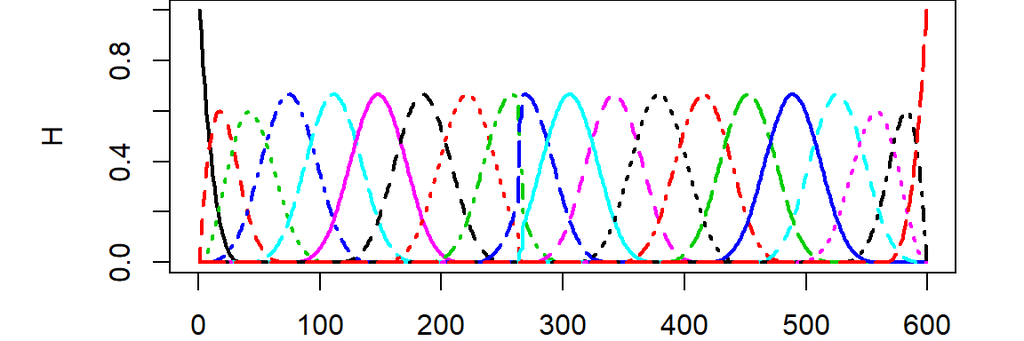

```r
H = load_H(20, index)
par(mar = c(2, 5, 0, 2))
matplot(H, type = 'l', lwd = 2)
```

# PCMS

*Principal Curve Metric Scaling (PCMS)* solves (classical) MDS problem equipped with the smooth curve constraint:
$$\text{minimize } \|C-XX^T\|^2_F \text{ w.r.t. }
\Theta\in\mathbb{R}^{k\times 3} \text{ subject to } X = H\Theta.$$

PCMS approach assumes $H$ to be orthogonal matrix. Orthogonalize $H$ from previous part by means of QR decomposition and run function to find PCMS reconstruction. To make the result to be compatible with Poisson Metric Scaling described below we apply PCMS technique to the log-transformed contact matrix $C^{\log}$.

```r
H = qr.Q(qr(H))
solution_PCMS = WPCMS(Clog, H, W = NULL)
cat('Optimal loss value is', solution_PCMS$loss)
```

```
## Optimal loss value is 24.47476
```

# Visualiztion

Plot contact matrix approximation $\hat {C}^{\log} = XX^T$ using .

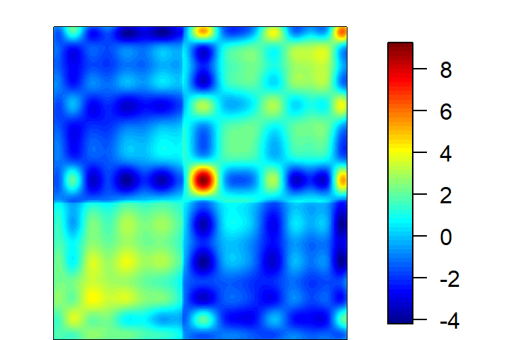

```r
par(mar = c(0, 2, 1, 2))
visualize(solution_PCMS$X, index, type = 'heatmap')
```

Plot projections of 3D reconstruction using .

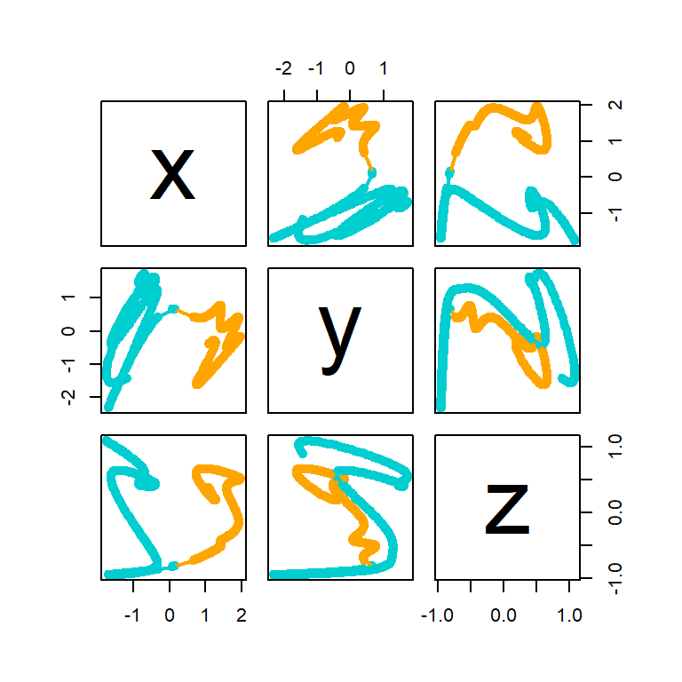

```r
visualize(solution_PCMS$X, index, type = 'projection')
```

One can also use to create interactive 3D plot of the reconstruction.

# WPCMS

*Weighted Principal Curve Metric Scaling (WPCMS)* is a weighted generalization of PCMS problem:
$$\text{minimize } \|W*(C-XX^T)\|^2_F \text{ w.r.t. }
\Theta\in\mathbb{R}^{k\times 3} \text{ subject to } X = H\Theta.$$
Here $*$ refers to the Hadamard product and $W\in[0,1]^{n\times n}$ is some symmetric matrix of weights.

Let’s create some $W$, for example, using uniform distribution.

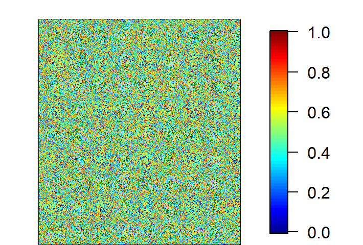

```r
set.seed(1)
W = matrix(runif(n_obs*n_obs), n_obs, n_obs)
W = (W + t(W))/2
par(mar = c(0, 2, 1, 2))
image.plot(W, xaxt='n', yaxt = 'n')
```

One can run to find WPCMS solution for log-transformed contact matrix $C^{log}$ and plot projections of WPCMS reconstruction. It takes 7 iterations to converge.

```r
solution_WPCMS = WPCMS(Clog, H, W = W, verbose = TRUE, eps = 1e-7)
```

```
## Iter: 0 WPCMS objective: 12.26138 Delta WPCMS objectives: Inf
## Iter: 1 Rate: 1 WPCMS Objective: 12.2606 Delta WPCMS objectives: 6.391909e-05
## Iter: 2 Rate: 1 WPCMS Objective: 12.26038 Delta WPCMS objectives: 1.781551e-05
## Iter: 3 Rate: 1 WPCMS Objective: 12.26031 Delta WPCMS objectives: 5.261886e-06
## Iter: 4 Rate: 1 WPCMS Objective: 12.26029 Delta WPCMS objectives: 1.601872e-06
## Iter: 5 Rate: 1 WPCMS Objective: 12.26029 Delta WPCMS objectives: 5.023456e-07
## Iter: 6 Rate: 1 WPCMS Objective: 12.26029 Delta WPCMS objectives: 1.628068e-07
## Iter: 7 Rate: 1 WPCMS Objective: 12.26029 Delta WPCMS objectives: 5.473433e-08
```

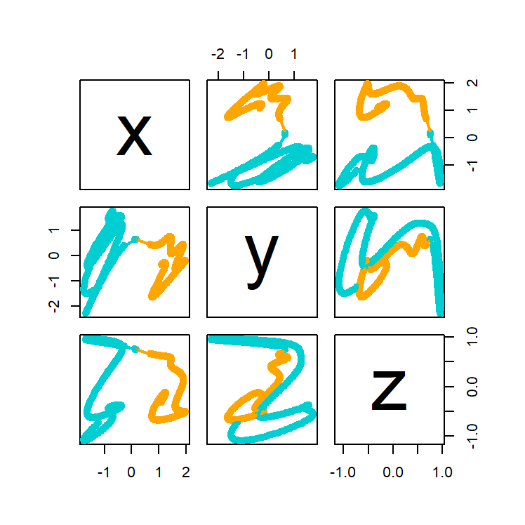

```r
visualize(solution_WPCMS$X, index, type = 'projection')
```

Note that if $W$ is a binary matrix, i.e. $W\in \{0,1\}^{n\times n}$, WPCMS treats the elements with zero weights as missing.

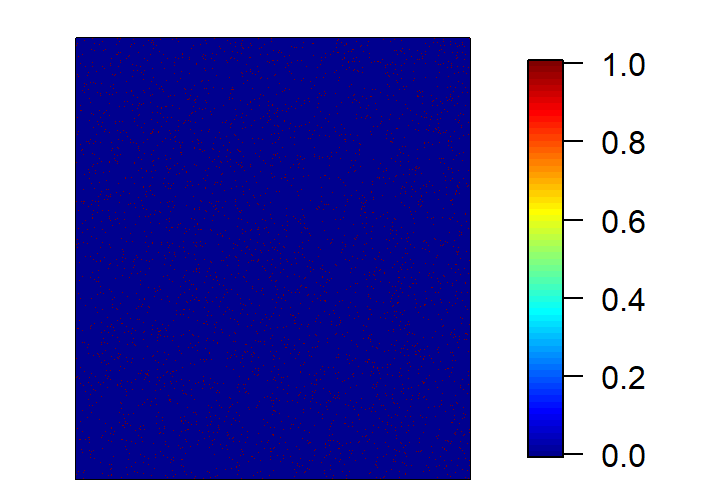

```r
W = (W > 0.9) * 1
par(mar = c(0, 2, 1, 2))
image.plot(round(W), xaxt='n', yaxt = 'n')
```

Let’s check how does the contact matrix approximation look like in the case of missing values.

```r
solution_WPCMS = WPCMS(Clog, H, W = W, eps = 1e-7, maxiter = 1000)
cat('Takes', solution_WPCMS$iter, 'iterations to converge')
```

```
## Takes 664 iterations to converge
```

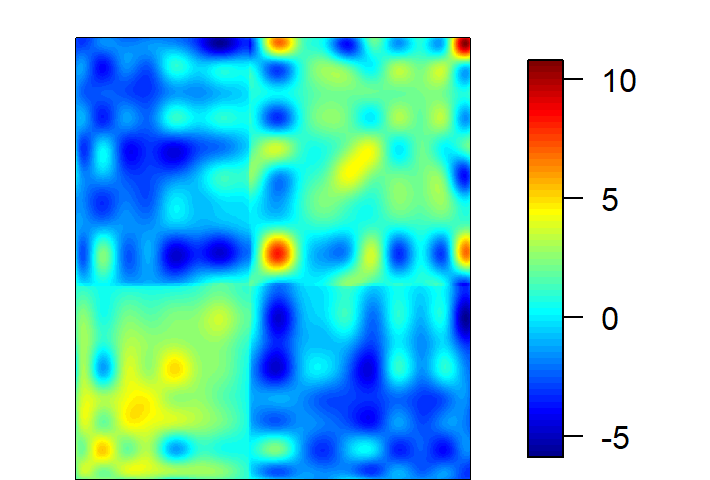

```r
par(mar = c(0, 2, 1, 2))
visualize(solution_WPCMS$X, index, type = 'heatmap')
```

# PoisMS

*Poisson Metric Scaling (PoisMS)* approach models contact counts by a Poisson distribution:
$$C_{ij}\sim Pois(\lambda_{ij}),~~\log(\lambda_{ij}) = \alpha \langle x_i, x_j\rangle + \beta.$$
Here $\alpha>0$ and $\beta\in\mathbb{R}$ are scaling and centering hyperparameters, respectively. The optimization problem is, therefore, to find minimum of the negative log-likelihood under the smooth curve constraint:
$$\text{minimize } \sum_{1 \leq i,j \leq n} \left[e^{\alpha \langle x_i, x_j\rangle + \beta} - C_{ij}\left(\alpha \langle x_i, x_j\rangle + \beta\right) \right] \text{ w.r.t. } X \text{ subject to } X = H\Theta.$$
Since the log-transformation is implicitly introduced in the model through $\log(\lambda_{ij}) = \alpha \langle x_i, x_j\rangle + \beta,$ we apply the PoisMS technique to the original data $C$, but with the same $\alpha$ and $\beta$ from log-transformation.

Run function to calculate the PoisMS solution, the algorithm converged in $8$ epochs.

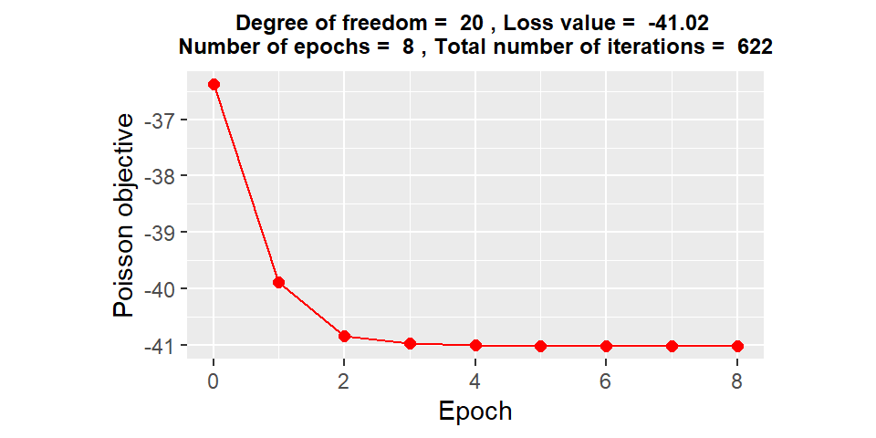

```r
C = C[index, index]
solution_PoisMS = PoisMS(C, H, alpha, beta, eps_wpcms = 1e-7, eps_poisms = 1e-6)
solution_PoisMS$plot
```

Plot the corresponding contact matrix approximation.

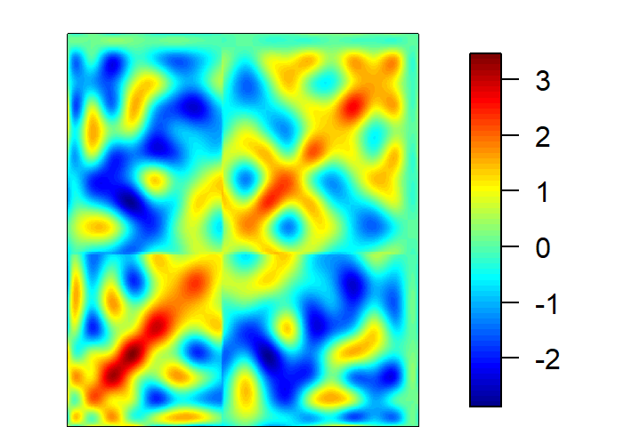

```r
par(mar = c(0, 2, 1, 2))
visualize(solution_PoisMS$X, index, type = 'heatmap')
```

Plot projections of 3D reconstruction.

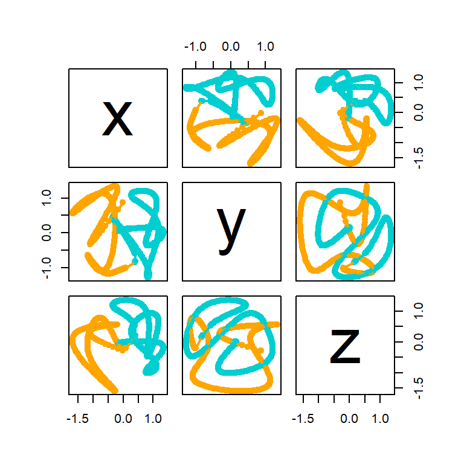

```r
visualize(solution_PoisMS$X, index, type = 'projection')
```

# Vary degrees-of-freedom

The main hyperparameter for the PCMS and PoisMS approaches is the spline degrees-of-freedom $df$ controlling the reconstruction smoothness. Calculate PCMS and PoisMS solutions for different degrees-of-freedom values.

```r
dfs = c(10, 25, 50, 100, 150, 200)
solutions = c()
for(df in dfs){
    H = load_H(df, index)
    H = qr.Q(qr(H))
    solutions = rbind(solutions, data.frame(WPCMS(Clog, H, W = NULL)$X, 'DF' = df, 'method' = 'PCMS'))
    solutions = rbind(solutions, data.frame(PoisMS(C, H, alpha, beta, eps_wpcms = 1e-7, eps_poisms = 1e-6)$X, 'DF' = df, 'method' = 'PoisMS'))
}
```

Compare heatmaps.

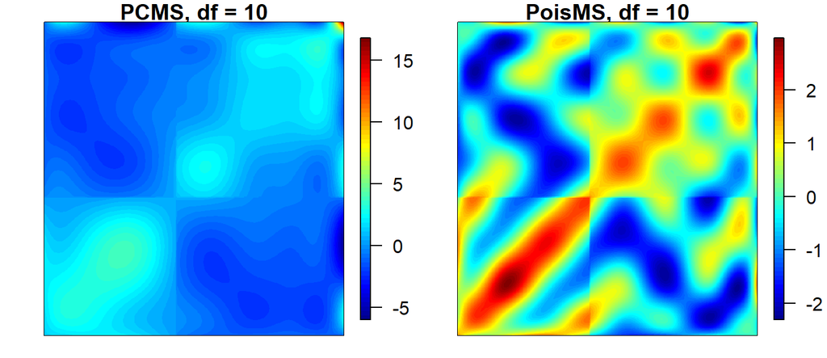

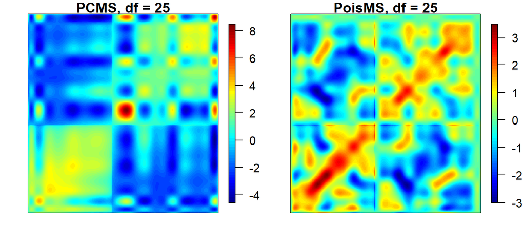

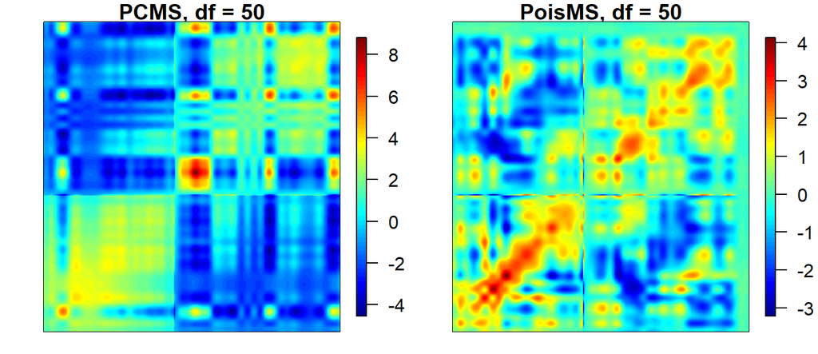

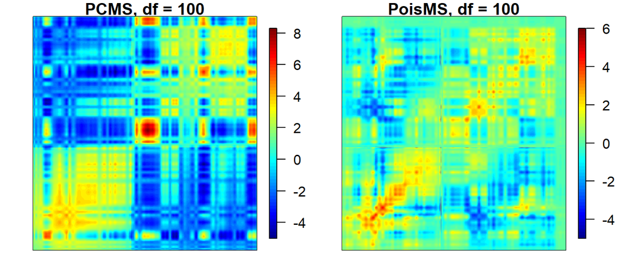

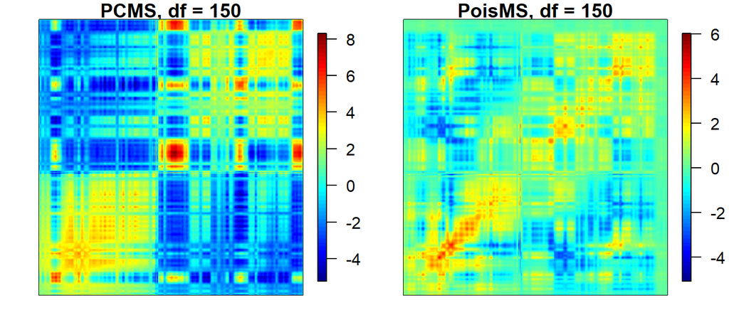

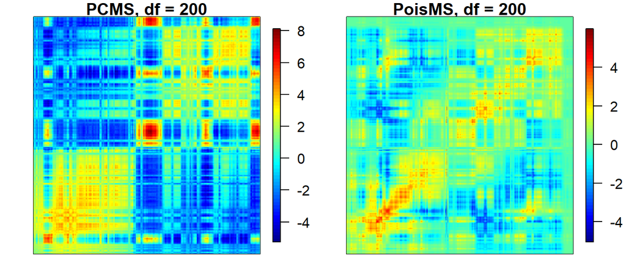

```r
for(df in dfs){
  par(mar = c(1, 2, 1, 2), mfrow = c(1,2))
  visualize(as.matrix(subset(solutions, method == 'PCMS' & DF == df)[,1:3]), index, type = 'heatmap', title = paste('PCMS, df =', df))
  visualize(as.matrix(subset(solutions, method == 'PoisMS' & DF == df)[,1:3]), index, type = 'heatmap', title = paste('PoisMS, df =', df))
}
```

Compare projections.

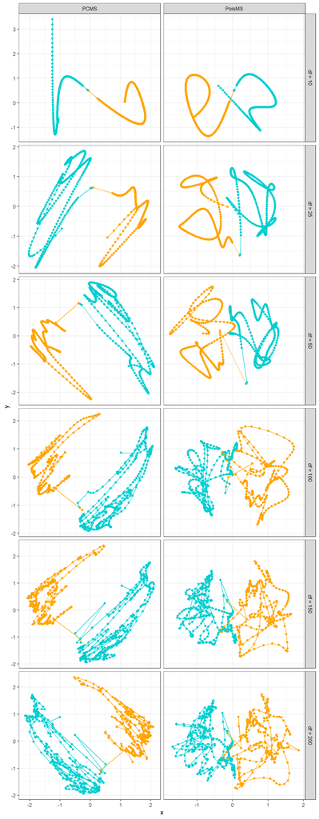

```r
library(ggplot2)
before_centromere = which(index < (n * 0.45))
after_centromere = which(index >= (n * 0.45))
col = c(rep('orange', length(before_centromere)), rep('darkturquoise', length(after_centromere)))
solutions = data.frame(solutions, col)
solutions$DF = factor(paste('df =', solutions$DF), levels = paste('df =', dfs))
ggplot(solutions, aes(X1, X2))+
  geom_point(color = solutions$col)+
  geom_path(color = solutions$col)+
  facet_grid(rows = vars(DF), cols = vars(method), scales = 'free')+
  xlab('x')+
  ylab('y')+
  theme_bw()
```

Low $df$ reconstructions capture only general structure, high $df$ reconstructions lose smoothness property.

# Pick optimal degrees-of-freedom value (PCMS example)

Vary degrees-of-freedom value and calculate the loss value for each obtained PCMS reconstruction.

```r
dfs = seq(5, 200, 5)
loss = c()
for(df in dfs){
  H = load_H(df, index)
  H = qr.Q(qr(H))
  solution = WPCMS(Clog, H, W = NULL)
  loss = append(loss, solution$loss)
}
```

The loss is decreasing with the growth of $df$.

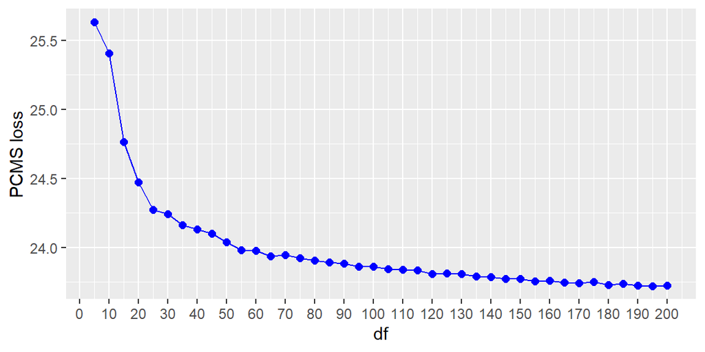

```r
data = data.frame(dfs, loss)
g = ggplot(data, aes(dfs, loss))+
  geom_point(color = 'blue', size = 2)+
  geom_line(color = 'blue')+
  scale_x_continuous(breaks =  seq(0, 200, 10))+
  ylab('PCMS loss')+
  xlab('df')
g
```

Use segmented regression to determine the kink location (thus, optimal value of $df$).

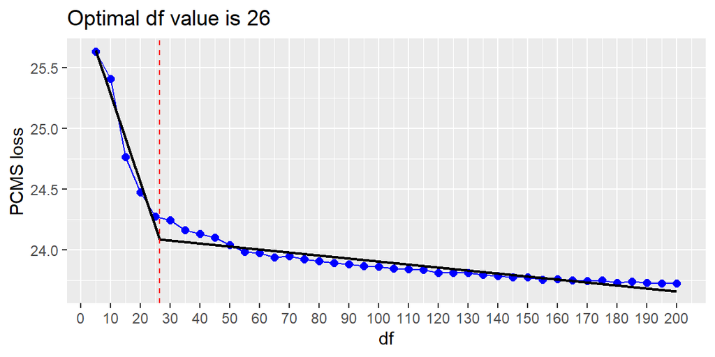

```r
library(segmented)
LR <- lm(loss ~ dfs, data = data)
SR <- segmented(LR, seg.Z = ~ dfs, npsi = 1, tol = 1e-6, it.max = 1000)
kink = SR$psi[2]
prediction = predict(object = SR, newdata = data.frame('dfs' = c(min(dfs), kink, max(dfs))))
newdata = data.frame('dfs' = c(min(dfs), kink, max(dfs)), 'loss' = prediction)
g+
  geom_line(newdata, mapping = aes(dfs, loss), colour = 'black', size = 0.8)+
  geom_vline(xintercept = kink, color = 'red', size = 0.4, linetype = 'dashed')+
  ggtitle(paste('Optimal df value is', round(kink)))
```